# Designing and Creating a Database

Sofiane Ikkour

**Context and objective:**  
In this project, we will work with data related to [Major League Baseball](https://en.wikipedia.org/wiki/Major_League_Baseball) compiled by [Retrosheet](https://www.retrosheet.org/). Retrosheet is non-profit organization that’s gathered game statistics from the 1800s to today. The goal is to convert and normalize this data into several separate tables using SQL and create a robust database of the game statistics.

**Note:** This code was written on RStudio.  
**Programming language:** SQL & R.  
**Packages:** readr, RSQLite, DBI, do.

**Load the datasets into R**

```r
# load the relevant libraries
library(readr)
library(do)
library(RSQLite)
library(DBI)

# set working directory
setwd("C:/Users/Aylan/Documents/IT/DataQuest/R/Designing and Creating a Database")

# load and read the main dataset (game_log.csv)
game_log <- read_csv("game_log.csv", col_types = cols(.default = "c"))

# display the first few rows
print(head(game_log, 10))
```

```
## # A tibble: 10 x 161
##    date     number_of_game day_of_week v_name v_league v_game_number h_name
##    <chr>    <chr>          <chr>       <chr>  <chr>    <chr>         <chr>
##  1 18710504 0              Thu         CL1    <NA>     1             FW1
##  2 18710505 0              Fri         BS1    <NA>     1             WS3
##  3 18710506 0              Sat         CL1    <NA>     2             RC1
##  4 18710508 0              Mon         CL1    <NA>     3             CH1
##  5 18710509 0              Tue         BS1    <NA>     2             TRO
##  6 18710511 0              Thu         CH1    <NA>     2             CL1
##  7 18710513 0              Sat         WS3    <NA>     2             CL1
##  8 18710513 0              Sat         CH1    <NA>     3             FW1
##  9 18710515 0              Mon         WS3    <NA>     3             FW1
## 10 18710516 0              Tue         TRO    <NA>     2             BS1
## # ... with 154 more variables: h_league <chr>, h_game_number <chr>,
## #   v_score <chr>, h_score <chr>, length_outs <chr>, day_night <chr>,
## #   completion <chr>, forfeit <chr>, protest <chr>, park_id <chr>,
## #   attendance <chr>, length_minutes <chr>, v_line_score <chr>,
## #   h_line_score <chr>, v_at_bats <chr>, v_hits <chr>, v_doubles <chr>,
## #   v_triples <chr>, v_homeruns <chr>, v_rbi <chr>, v_sacrifice_hits <chr>,
## #   v_sacrifice_flies <chr>, v_hit_by_pitch <chr>, v_walks <chr>, ...
```

```r
# print the number of rows and columns the game_log.csv dataset
print(paste("The number of rows of the game_log.csv dataset is:", nrow(game_log)))
```

```
## [1] "The number of rows of the game_log.csv dataset is: 171907"
```

```r
print(paste("The number of columns of the game_log.csv dataset is:", ncol(game_log)))
```

```
## [1] "The number of columns of the game_log.csv dataset is: 161"
```

```r
# load and read the helper file park_codes.csv
park_codes <- read_csv("park_codes.csv", col_types = cols())

# display the first few rows
print(head(park_codes, 10))
```

```
## # A tibble: 10 x 9
##    park_id name       aka          city   state start  end   league notes
##    <chr>   <chr>      <chr>        <chr>  <chr> <chr>  <chr> <chr>  <chr>
##  1 ALB01   Riverside~ <NA>         Albany NY    09/11~ 05/3~ NL     TRN:9/11/80~
##  2 ALT01   Columbia ~ <NA>         Altoo~ PA    04/30~ 05/3~ UA     <NA>
##  3 ANA01   Angel Sta~ Edison Fiel~ Anahe~ CA    04/19~ <NA>  AL     <NA>
##  4 ARL01   Arlington~ <NA>         Arlin~ TX    04/21~ 10/0~ AL     <NA>
##  5 ARL02   Rangers B~ The Ballpar~ Arlin~ TX    04/11~ <NA>  AL     <NA>
##  6 ATL01   Atlanta-F~ <NA>         Atlan~ GA    04/12~ 09/2~ NL     <NA>
##  7 ATL02   Turner Fi~ <NA>         Atlan~ GA    04/04~ 10/0~ NL     <NA>
##  8 ATL03   Suntrust ~ <NA>         Atlan~ GA    04/14~ <NA>  NL     <NA>
##  9 BAL01   Madison A~ <NA>         Balti~ MD    07/08~ 07/0~ <NA>   WS3
## 10 BAL02   Newington~ <NA>         Balti~ MD    04/22~ 09/3~ <NA>   BL1:1872-74~
```

```r
# print the number of rows and columns the park_codes.csv dataset
print(paste("The number of rows of the park_codes.csv dataset is:", nrow(park_codes)))
```

```
## [1] "The number of rows of the park_codes.csv dataset is: 252"
```

```r
print(paste("The number of columns of the park_codes.csv dataset is:", ncol(park_codes)))
```

```
## [1] "The number of columns of the park_codes.csv dataset is: 9"
```

```r
# load and read the helper file person_codes.csv
person_codes <- read_csv("person_codes.csv", col_types = cols())

# display the first few rows
print(head(person_codes, 10))
```

```
## # A tibble: 10 x 7
##    id       last        first    player_debut mgr_debut coach_debut ump_debut
##    <chr>    <chr>       <chr>    <chr>        <chr>     <chr>       <chr>
##  1 aardd001 Aardsma     David    04/06/2004   <NA>      <NA>        <NA>
##  2 aaroh101 Aaron       Hank     04/13/1954   <NA>      <NA>        <NA>
##  3 aarot101 Aaron       Tommie   04/10/1962   <NA>      04/06/1979  <NA>
##  4 aased001 Aase        Don      07/26/1977   <NA>      <NA>        <NA>
##  5 abada001 Abad        Andy     09/10/2001   <NA>      <NA>        <NA>
##  6 abadf001 Abad        Fernando 07/28/2010   <NA>      <NA>        <NA>
##  7 abadj101 Abadie      John     04/26/1875   <NA>      <NA>        <NA>
##  8 abbae101 Abbaticchio Ed       09/04/1897   <NA>      <NA>        <NA>
##  9 abbeb101 Abbey       Bert     06/14/1892   <NA>      <NA>        <NA>
## 10 abbec101 Abbey       Charlie  08/16/1893   <NA>      <NA>        07/21/1897
```

```r
# print the number of rows and columns the person_codes.csv dataset
print(paste("The number of rows of the person_codes.csv dataset is:", nrow(person_codes)))
```

```
## [1] "The number of rows of the person_codes.csv dataset is: 20494"
```

```r
print(paste("The number of columns of the person_codes.csv dataset is:", ncol(person_codes)))
```

```
## [1] "The number of columns of the person_codes.csv dataset is: 7"
```

```r
# load and read the helper file team_codes.csv
team_codes <- read_csv("team_codes.csv", col_types = cols())

# display the first few rows
print(head(team_codes, 10))
```

```
## # A tibble: 10 x 8
##    team_id league start   end city      nickname        franch_id   seq
##    <chr>   <chr>  <dbl> <dbl> <chr>     <chr>           <chr>     <dbl>
##  1 ALT     UA      1884  1884 Altoona   Mountain Cities ALT           1
##  2 ARI     NL      1998     0 Arizona   Diamondbacks    ARI           1
##  3 BFN     NL      1879  1885 Buffalo   Bisons          BFN           1
##  4 BFP     PL      1890  1890 Buffalo   Bisons          BFP           1
##  5 BL1     <NA>    1872  1874 Baltimore Canaries        BL1           1
##  6 BL2     AA      1882  1891 Baltimore Orioles         BL2           1
##  7 BLN     NL      1892  1899 Baltimore Orioles         BL2           2
##  8 BL4     <NA>    1873  1873 Baltimore Marylands       BL4           1
##  9 BLA     AL      1901  1902 Baltimore Orioles         BLA           1
## 10 NYA     AL      1903     0 New York  Yankees         BLA           2
```

```r
# print the number of rows and columns the team_codes.csv dataset
print(paste("The number of rows of the team_codes.csv dataset is:", nrow(team_codes)))
```

```
## [1] "The number of rows of the team_codes.csv dataset is: 150"
```

```r
print(paste("The number of columns of the team_codes.csv dataset is:", ncol(team_codes)))
```

```
## [1] "The number of columns of the team_codes.csv dataset is: 8"
```

```r
# load and read the helper file appearance_type.csv
appearance_type <- read_csv("appearance_type.csv", col_types = cols())

# display the first few rows
print(head(appearance_type, 10))
```

```
## # A tibble: 10 x 3
##    appearance_type_id name     category
##    <chr>              <chr>    <chr>
##  1 O1                 Batter 1 offense
##  2 O2                 Batter 2 offense
##  3 O3                 Batter 3 offense
##  4 O4                 Batter 4 offense
##  5 O5                 Batter 5 offense
##  6 O6                 Batter 6 offense
##  7 O7                 Batter 7 offense
##  8 O8                 Batter 8 offense
##  9 O9                 Batter 9 offense
## 10 D1                 Pitcher  defense
```

```r
# print the number of rows and columns the appearance_type.csv dataset
print(paste("The number of rows of the appearance_type.csv dataset is:", nrow(appearance_type)))
```

```
## [1] "The number of rows of the appearance_type.csv dataset is: 31"
```

```r
print(paste("The number of columns of the appearance_type.csv dataset is:", ncol(appearance_type)))
```

```
## [1] "The number of columns of the appearance_type.csv dataset is: 3"
```

**Observations:**

- The main dataset is very large with 171907 rows and 161 columns. After carefully analyzing the column names, my attention is focused on on the first few columns like v_name, h_name and v_game_number whose contents seem to be used as IDs of some kind. The date column can also be useful for manipulating the data.
- The first helper file, park_codes.csv, has 252 rows and 9 columns. The first column is named parked_id, a column we can find in the main file. This column is useful in case we want to join the two datasets.
- The second helper file, person_codes, has 20494 rows and 7 columns and it seems to contain information about players like player names, player career debuts and coach career debuts.
- The third helper file, team_codes, as the name suggests contains information about different teams of the game like team_id, nicknames and the city from which the team originated.
- The fourth helper file, appearance_type, has 31 rows and 3 columns and include data on players with positions, umpires, managers and awards.

You can refer to the additional game_log_fields.txt file provided for more detailed descriptions about the main dataset. It can help understand the data better.

**First step - data normalization**

The first step is to designate a primary key. The main file game_log.csv doesn’t have a column that we can be used as a primary key. One way we can handle this is by using a system provided by Retrosheet for uniquely identifying each game. We can find this [data dictionary](https://www.retrosheet.org/eventfile.htm) on the Restrosheet website for their event files, which list every event for each game. This dictionary includes the following description:

**id:** Each game begins with a twelve character ID record which identifies the date, home team, and number of the game. For example, ATL198304080 should be read as follows. The first three characters identify the home team (the Braves). The next four are the year (1983). The next two are the month (April) using the standard numeric notation, 04, followed by the day (08). The last digit indicates if this is a single game (0), first game (1) or second game (2) if more than one game is played during a day, usually a double header The id record starts the description of a game thus ending the description of the preceding game in the file.

This is a custom key we will construct for the main dataset. But first, we need to import our csv files into SQLite.

```r
# create a new SQLite database named mlb.db
mlb <- dbConnect(SQLite(), "mlb.db")

# create a table for the game_log.csv file into the new SQLite database
dbWriteTable(conn = mlb, name = "game_log", value = game_log, header = TRUE)

# create a table for the park_codes.csv file into the new SQLite database
dbWriteTable(conn = mlb, name = "park_codes", value = park_codes, header = TRUE)

# create a table for the person_codes.csv file into the new SQLite database
dbWriteTable(conn = mlb, name = "person_codes", value = person_codes, header = TRUE)

# create a table for the team_codes.csv file into the new SQLite database
dbWriteTable(conn = mlb, name = "team_codes", value = team_codes, header = TRUE)

# write a query that creates a new column named game_id for the game_log table
game_log_col <- 'ALTER TABLE game_log
                 ADD COLUMN game_id TEXT;'

# execute the query
dbExecute(conn = mlb, game_log_col)
```

```
## [1] 0
```

```r
# combine h_name, date and number of game and the result to the new column
game_log_update <- 'UPDATE game_log
                    SET game_id = h_name || date || number_of_game
                    WHERE game_id IS NULL;'

# execute the query
dbExecute(conn = mlb, game_log_update)
```

```
## [1] 171907
```

```r
# display the new table
q <- 'SELECT date, number_of_game, h_name, game_id FROM game_log;'
head(dbGetQuery(conn = mlb, q), 10)
```

```
##        date number_of_game h_name      game_id
## 1  18710504              0    FW1 FW1187105040
## 2  18710505              0    WS3 WS3187105050
## 3  18710506              0    RC1 RC1187105060
## 4  18710508              0    CH1 CH1187105080
## 5  18710509              0    TRO TRO187105090
## 6  18710511              0    CL1 CL1187105110
## 7  18710513              0    CL1 CL1187105130
## 8  18710513              0    FW1 FW1187105130
## 9  18710515              0    FW1 FW1187105150
## 10 18710516              0    BS1 BS1187105160
```

**Second step - data normalization:**

The second step in data normalization is to plan a schema by visually creating a diagram of the four existing tables and their columns.  
I used the database design online tool DbDesigner.net which allows to create a schema and lines that show foreign key relations.  
Below is the first suggested schema diagram:

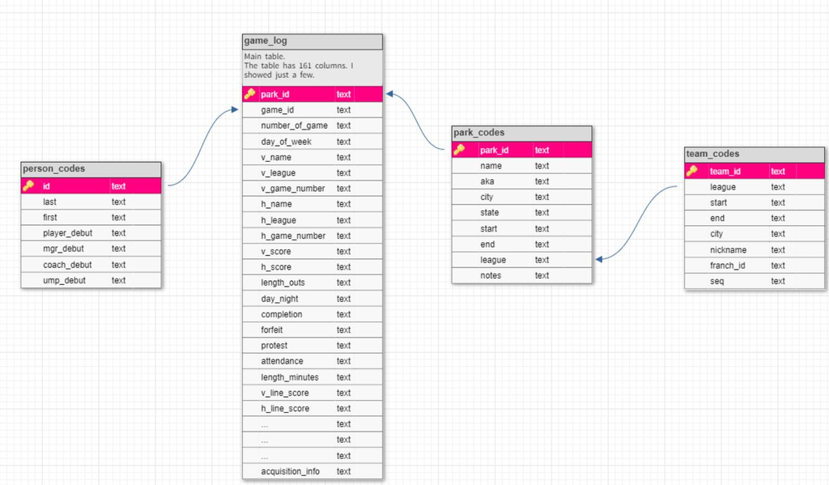

Schema diagram

Looking at the schema diagram, we obviously need to move the data into a more normalized state by creating new tables.

**Discussion:**  
- If we take a close look at the game_log table, we can notice that some columns contain the same information as the next three columns. The subset of these columns start from the column v_player_1_id to v_player_9_def_pos. The same logic applies from the column h_player_1_id to h_player_9_def_pos. These columns can be stacked on one another to remove this repetition.  
- The start and end columns of the park_codes table indicate dates for the first and last games played at the park. These columns can be removed since the same information can be derived from the game_log table. The logic applies for the team_codes table where the start and end columns can be reproduced from the game_log table.  
- The player_debut column can be reproduced using the game_log table.  
- We have some columns in the game_log table where a player_id is followed by a player name. We can remove these columns and use the player names we can find in the person_codes table instead.  
- In the game_log table, all defensive and offensive statistics are repeated for the visiting and home teams. We can remove this repetition by listing each game twice and associate each category of statistics for each game.

With all these observations made, we start by creating new tables without foreign relations since other tables will have relations to these tables.

```r
# create a table named person derived from the person_codes table
create_person_table <- "CREATE TABLE IF NOT EXISTS person (
                            person_id TEXT PRIMARY KEY,
                            first_name TEXT,
                            last_name TEXT
                        );"

# execute the query
dbExecute(conn = mlb, create_person_table)
```

```
## [1] 0
```

```r
# the debut columns are removed because the will be derived from other tables
# the coach_debut column is removed definitely because it does not exist in the game_log table

# insert the data from the person_codes table into the person table
insert_person_table <-  "INSERT OR IGNORE INTO person
                         SELECT
                            id,
                            first,
                            last
                         FROM person_codes;"

# execute the query
dbExecute(conn = mlb, insert_person_table)
```

```
## [1] 20494
```

```r
# display the first few rows of the person table
q_person <- "SELECT * FROM person LIMIT 10;"
dbGetQuery(conn = mlb, q_person) # get the query
```

```
##    person_id first_name   last_name
## 1   aardd001      David     Aardsma
## 2   aaroh101       Hank       Aaron
## 3   aarot101     Tommie       Aaron
## 4   aased001        Don        Aase
## 5   abada001       Andy        Abad
## 6   abadf001   Fernando        Abad
## 7   abadj101       John      Abadie
## 8   abbae101         Ed Abbaticchio
## 9   abbeb101       Bert       Abbey
## 10  abbec101    Charlie       Abbey
```

```r
# create a table named park derived from the park_codes table
create_park_table <- "CREATE TABLE IF NOT EXISTS park (
                            park_id TEXT PRIMARY KEY,
                            name TEXT,
                            aka_name TEXT,
                            city,
                            state,
                            notes
                          );"

# the start, end and league columns are removed as they can be derived from the game_log table

# execute the query
dbExecute(conn = mlb, create_park_table)
```

```
## [1] 0
```

```r
# insert data from the park_codes table into the new park table
insert_park_table <- "INSERT OR IGNORE INTO park
                      SELECT
                         park_id,
                         name,
                         aka,
                         city,
                         state,
                         notes
                      FROM park_codes;"

# execute the query
dbExecute(conn = mlb, insert_park_table)
```

```
## [1] 252
```

```r
# display the first few rows of the park table
q_park <- "SELECT * FROM park LIMIT 10;"
dbGetQuery(conn = mlb, q_park) # get the query
```

```
##    park_id                          name
## 1    ALB01                Riverside Park
## 2    ALT01                 Columbia Park
## 3    ANA01      Angel Stadium of Anaheim
## 4    ARL01             Arlington Stadium
## 5    ARL02 Rangers Ballpark in Arlington
## 6    ATL01 Atlanta-Fulton County Stadium
## 7    ATL02                  Turner Field
## 8    ATL03                 Suntrust Park
## 9    BAL01        Madison Avenue Grounds
## 10   BAL02                Newington Park
##                                    aka_name      city state
## 1                                      <NA>    Albany    NY
## 2                                      <NA>   Altoona    PA
## 3             Edison Field; Anaheim Stadium   Anaheim    CA
```

[output cut: 18 more lines]

I wanted to create a table that contains a list of the different leagues. First of all, let’s look at how many leagues are mentioned in the park_codes table.

```r
# display unique values for the league column in the park_codes table
unique_no.NA(park_codes$league)
```

```
## [1] "NL" "UA" "AL" "AA" "FL" "PL"
```

There are six different leagues mentioned in the park_codes table. After researching these acronyms with the help of Google, I found the names associated for each league acronym: - NL: National League. You can find more information on [this Wikipedia link](https://en.wikipedia.org/wiki/National_League).  
- UA: Union Association. You can find more information on [this Wikipedia link](https://en.wikipedia.org/wiki/Union_Association).  
- AL: American League. You can find more information on [this Wikipedia link](https://en.wikipedia.org/wiki/Union_Association).  
- AA: American Association. You can find more information on [this Wikipedia link](https://en.wikipedia.org/wiki/American_Association_of_Professional_Baseball).  
- FL: Federal League. You can find more information on [this Wikipedia link](https://en.wikipedia.org/wiki/Federal_League).  
- PL: Player’s League. You can find more information on [this Wikipedia link](https://en.wikipedia.org/wiki/Players%27_League).

Let’s create a table that contains two columns: the acronym and the name of each league.

```r
# create a table named league
create_league_table <- "CREATE TABLE IF NOT EXISTS league (
                           league_id TEXT PRIMARY KEY,
                          league_name TEXT
                        );"

# execute the query
dbExecute(conn = mlb, create_league_table)
```

```
## [1] 0
```

```r
# insert data into the new league table
insert_league_table <- "INSERT OR IGNORE INTO league
                        VALUES
                             ('NL', 'National League'),
                             ('UN', 'Union Association'),
                             ('AL', 'American League'),
                             ('AA', 'American Association'),
                             ('FL', 'Federal League'),
                             ('PL', 'Players League');"

# execute the query
dbExecute(conn = mlb, insert_league_table)
```

```
## [1] 6
```

```r
# display the rows
q_league <- "SELECT * FROM league;"
dbGetQuery(conn = mlb, q_league) # get the query
```

```
##   league_id          league_name
## 1        NL      National League
## 2        UN    Union Association
## 3        AL      American League
## 4        AA American Association
## 5        FL       Federal League
## 6        PL       Players League
```

Next, we need to create an appearance_type table using the data from appearance_type.csv file.

```r
# create a table for the appearance_type.csv file into the new SQLite database
dbWriteTable(conn = mlb, name = "appearance_type", value = appearance_type, header = TRUE)

# display the first few rows
q_appearance_type <- "SELECT * FROM appearance_type LIMIT 10;"
dbGetQuery(conn = mlb, q_appearance_type)
```

```
##    appearance_type_id     name category
## 1                  O1 Batter 1  offense
## 2                  O2 Batter 2  offense
## 3                  O3 Batter 3  offense
## 4                  O4 Batter 4  offense
## 5                  O5 Batter 5  offense
## 6                  O6 Batter 6  offense
## 7                  O7 Batter 7  offense
## 8                  O8 Batter 8  offense
## 9                  O9 Batter 9  offense
## 10                 D1  Pitcher  defense
```

Two tables named game and team are added. Below is a reduced schema diagram that shows the two tables with the already created tables park and league and the foreign relations between them:

[figure not shown]

game_team schema

```r
# create the team table
create_team_table <- "CREATE TABLE team (
                          team_id TEXT PRIMARY KEY,
                          league_id TEXT,
                          city TEXT,
                          nickname TEXT,
                          franch_id,
                          FOREIGN KEY(league_id) REFERENCES league(league_id)
                         );"

# the start, end and seq columns can be derived from the game_log table

# execute the query
dbExecute(conn = mlb, create_team_table)
```

```
## [1] 0
```

```r
# insert data from the team_codes table into the team table
insert_team_table <- "INSERT OR IGNORE INTO team
                      SELECT
                         team_id,
                         league,
                         city,
                         nickname,
                         franch_id
                       FROM team_codes;"

# execute the query
dbExecute(conn = mlb, insert_team_table)
```

```
## [1] 150
```

```r
# display the first few rows
q_team <- "SELECT * FROM team LIMIT 10;"
dbGetQuery(conn = mlb, q_team) # get the query
```

```
##    team_id league_id      city        nickname franch_id
## 1      ALT        UA   Altoona Mountain Cities       ALT
## 2      ARI        NL   Arizona    Diamondbacks       ARI
## 3      BFN        NL   Buffalo          Bisons       BFN
## 4      BFP        PL   Buffalo          Bisons       BFP
## 5      BL1      <NA> Baltimore        Canaries       BL1
## 6      BL2        AA Baltimore         Orioles       BL2
## 7      BLN        NL Baltimore         Orioles       BL2
## 8      BL4      <NA> Baltimore       Marylands       BL4
## 9      BLA        AL Baltimore         Orioles       BLA
## 10     NYA        AL  New York         Yankees       BLA
```

```r
# create the game table
create_game_table <- "CREATE TABLE game (
                           game_id TEXT PRIMARY KEY,
                           date DATE,
                           number_of_game INT,
                           park_id TEXT,
                           length_outs INT,
                           day TEXT,
                           completion TEXT,
                           forfeit TEXT,
                           protest TEXT,
                           attendance INT,
                           length_minutes INT,
                           additional_info TEXT,
                           acquisition_info TEXT,
                           FOREIGN KEY(park_id) REFERENCES park(park_id)
                        );"

# execute the query
dbExecute(conn = mlb, create_game_table)
```

```
## [1] 0
```

```r
# insert data into the game table
insert_game_table <- "INSERT OR IGNORE INTO game
                      SELECT
                         game_id,
                         date,
                         number_of_game,
                         park_id,
                         length_outs,
                         day_night,
                         completion,
                         forfeit,
                         protest,
                         attendance,
                         length_minutes,
                         additional_info,
                         acquisition_info
                      FROM game_log;"

# execute the query
dbExecute(conn = mlb, insert_game_table)
```

```
## [1] 171907
```

```r
# display the first few rows
q_game <- "SELECT * FROM game LIMIT 10;"
dbGetQuery(conn = mlb, q_game) # get the query
```

```
##         game_id     date number_of_game park_id length_outs day completion
## 1  FW1187105040 18710504              0   FOR01          54   D       <NA>
## 2  WS3187105050 18710505              0   WAS01          54   D       <NA>
## 3  RC1187105060 18710506              0   RCK01          54   D       <NA>
## 4  CH1187105080 18710508              0   CHI01          54   D       <NA>
## 5  TRO187105090 18710509              0   TRO01          54   D       <NA>
## 6  CL1187105110 18710511              0   CLE01          48   D       <NA>
## 7  CL1187105130 18710513              0   CIN01          54   D       <NA>
## 8  FW1187105130 18710513              0   FOR01          54   D       <NA>
## 9  FW1187105150 18710515              0   FOR01          54   D       <NA>
## 10 BS1187105160 18710516              0   BOS01          54   D       <NA>
##    forfeit protest attendance length_minutes additional_info acquisition_info
## 1     <NA>    <NA>        200            120            <NA>                Y
## 2     <NA>    <NA>       5000            145            HTBF                Y
## 3     <NA>    <NA>       1000            140            <NA>                Y
## 4     <NA>    <NA>       5000            150            <NA>                Y
## 5     <NA>    <NA>       3250            145            HTBF                Y
## 6        V    <NA>       2500            120            <NA>                Y
## 7     <NA>    <NA>       1200            150            <NA>                Y
## 8     <NA>    <NA>       1500            105            <NA>                Y
## 9     <NA>    <NA>         NA            140            <NA>                Y
## 10    <NA>    <NA>       2500             NA            HTBF                Y
```

The next table that will be created is named team_appearance. This table will have a compound primary key composed of team_id and game_id. It will also have a boolean column which differentiates the home and visitor teams. The rest of the columns will be scores and statistics derived from the game_log table. Below is a schema showing the new table with its relations with other tables:

[figure not shown]

team_appearance schema

```r
# create a table named team_appearance
create_team_appearance_table <- "CREATE TABLE IF NOT EXISTS team_appearance (
                                        team_id TEXT,
                                        game_id TEXT,
                                        home BOOLEAN,
                                        league_id TEXT,
                                        score INTEGER,
                                        line_score INTEGER,
                                        at_bats iNTEGER,
                                        hits INTEGER,
                                        doubles INTEGER,
                                        triples INTEGER,
                                        homeruns INTEGER,
                                        rbi INTEGER,
                                        sacrifice_hits,
                                        sacrifies_flies INTEGER,
                                        hit_by_pitch INTEGER,
                                        walks INTEGER,
                                        intentional_walks INTEGER,
                                        strikeouts INTEGER,
                                        stolen_bases INTEGER,
                                        caught_stealing INTEGER,
                                        grounded_into_double INTEGER,
                                        first_catcher_interfrence INTEGER,
                                        left_on_base INTEGER,
                                        pitchers_used INTEGER,
                                        individual_earned_runs INTEGER,
                                        team_earned_runs INTEGER,
                                        wild_pitches INTEGER,
                                        balks INTEGER,
                                        putouts INTEGER,
                                        assists INTEGER,
                                        errors INTEGER,
                                        passed_balls INTEGER,
                                        double_plays INTEGER,
                                        triple_plays INTEGER,
                                        PRIMARY KEY(team_id, game_id),
                                        FOREIGN KEY(league_id) REFERENCES league(league_id),
                                        FOREIGN KEY(team_id) REFERENCES team(team_id),
                                        FOREIGN KEY(game_id) REFERENCES game(game_id)
                                 );"

# execute the query
dbExecute(conn = mlb, create_team_appearance_table)
```

```
## [1] 0
```

```r
# insert data into the new created table derived from the game_log table
insert_team_appearance_table <- "INSERT OR IGNORE INTO team_appearance
                                 SELECT
                                    h_name,
                                    game_id,
                                    1 AS Home,
                                    h_league,
                                    h_score,
                                    h_line_score,
                                    h_at_bats,
                                    h_hits,
                                    h_doubles,
                                    h_triples,
                                    h_homeruns,
                                    h_rbi,
                                    h_sacrifice_hits,
                                    h_sacrifice_flies,
                                    h_hit_by_pitch,
                                    h_walks,
                                    h_intentional_walks,
                                    h_strikeouts,
                                    h_stolen_bases,
                                    h_caught_stealing,
                                    h_grounded_into_double,
                                    h_first_catcher_interference,
                                    h_left_on_base,
                                    h_pitchers_used,
                                    h_individual_earned_runs,
                                    h_team_earned_runs,
                                    h_wild_pitches,
                                    h_balks,
                                    h_putouts,
                                    h_assists,
                                    h_errors,
                                    h_passed_balls,
                                    h_double_plays,
                                    h_triple_plays
                                 FROM game_log
                             UNION
                                 SELECT
                                    v_name,
                                    game_id,
                                    0 AS Home,
                                    v_league,
                                    v_score,
                                    v_line_score,
                                    v_at_bats,
                                    v_hits,
                                    v_doubles,
                                    v_triples,
                                    v_homeruns,
                                    v_rbi,
                                    v_sacrifice_hits,
                                    v_sacrifice_flies,
                                    v_hit_by_pitch,
                                    v_walks,
                                    v_intentional_walks,
                                    v_strikeouts,
                                    v_stolen_bases,
                                    v_caught_stealing,
                                    v_grounded_into_double,
                                    v_first_catcher_interference,
                                    v_left_on_base,
                                    v_pitchers_used,
                                    v_individual_earned_runs,
                                    v_team_earned_runs,
                                    v_wild_pitches,
                                    v_balks,
                                    v_putouts,
                                    v_assists,
                                    v_errors,
                                    v_passed_balls,
                                    v_double_plays,
                                    v_triple_plays
                                 FROM game_log;"

# execute the query
dbExecute(conn = mlb, insert_team_appearance_table)
```

```
## [1] 343814
```

```r
# display the first fex row
q_team_appearance <- "SELECT * FROM team_appearance LIMIT 10;"
dbGetQuery(conn = mlb, q_team_appearance) # get the query
```

```
##    team_id      game_id home league_id score line_score at_bats hits doubles
## 1      ALT ALT188404300    1        UA     2         NA      NA   NA      NA
## 2      ALT ALT188405020    1        UA     3         NA      NA   NA      NA
## 3      ALT ALT188405030    1        UA     5         NA      NA   NA      NA
## 4      ALT ALT188405050    1        UA     2         NA      NA   NA      NA
## 5      ALT ALT188405100    1        UA     9         NA      NA   NA      NA
## 6      ALT ALT188405120    1        UA     3         NA      NA   NA      NA
## 7      ALT ALT188405140    1        UA     2         NA      NA   NA      NA
## 8      ALT ALT188405150    1        UA     7         NA      NA   NA      NA
## 9      ALT ALT188405160    1        UA     6         NA      NA   NA      NA
## 10     ALT ALT188405170    1        UA     8         NA      NA   NA      NA
##    triples homeruns rbi sacrifice_hits sacrifies_flies hit_by_pitch walks
## 1       NA       NA  NA             NA              NA           NA    NA
## 2       NA       NA  NA             NA              NA           NA    NA
## 3       NA       NA  NA             NA              NA           NA    NA
```

[output cut: 51 more lines]

The last table to be created will be named person_appearance. This table will store information on appearances on games by managers, players, and umpires as it is detailed in the appearance_type table.  
The diagram below shows the table and the different relations with other tables:

[figure not shown]

person_appearance schema

```r
# create a table named person_appearance
create_person_appearance_table <-
                  "CREATE TABLE IF NOT EXISTS person_appearance (
                     appearance_id TEXT PRIMARY KEY,
                     person_id TEXT,
                     team_id TEXT,
                     game_id TEXT,
                     appearance_type_id TEXT,
                     FOREIGN KEY(person_id) REFERENCES person(person_id),
                     FOREIGN KEY(team_id) REFERENCES team(team_id),
                     FOREIGN KEY(game_id) REFERENCES game(game_id),
                     FOREIGN KEY(appearance_type_id) REFERENCES appearance_type(appearance_type_id)
                  );"

# execute the query
dbExecute(conn = mlb, create_person_appearance_table)
```

```
## [1] 0
```

```r
# insert data into the table
insert_person_appearance_table <- '
  INSERT OR IGNORE INTO person_appearance (
      game_id,
      team_id,
      person_id,
      appearance_type_id
  )
      SELECT
          game_id,
          NULL,
          hp_umpire_id,
          "UHP"
      FROM game_log
      WHERE hp_umpire_id IS NOT NULL

  UNION

      SELECT
          game_id,
          NULL,
          [1b_umpire_id],
          "U1B"
      FROM game_log
      WHERE "1b_umpire_id" IS NOT NULL

  UNION

      SELECT
          game_id,
          NULL,
          [2b_umpire_id],
          "U2B"
      FROM game_log
      WHERE [2b_umpire_id] IS NOT NULL

  UNION

      SELECT
          game_id,
          NULL,
          [3b_umpire_id],
          "U3B"
      FROM game_log
      WHERE [3b_umpire_id] IS NOT NULL

  UNION

      SELECT
          game_id,
          NULL,
          lf_umpire_id,
          "ULF"
      FROM game_log
      WHERE lf_umpire_id IS NOT NULL

  UNION

      SELECT
          game_id,
          NULL,
          rf_umpire_id,
          "URF"
      FROM game_log
      WHERE rf_umpire_id IS NOT NULL

  UNION

      SELECT
          game_id,
          v_name,
          v_manager_id,
          "MM"
      FROM game_log
      WHERE v_manager_id IS NOT NULL

  UNION

      SELECT
          game_id,
          h_name,
          h_manager_id,
          "MM"
      FROM game_log
      WHERE h_manager_id IS NOT NULL

  UNION

      SELECT
          game_id,
          CASE
              WHEN h_score > v_score THEN h_name
              ELSE v_name
              END,
          winning_pitcher_id,
          "AWP"
      FROM game_log
      WHERE winning_pitcher_id IS NOT NULL

  UNION

      SELECT
          game_id,
          CASE
              WHEN h_score < v_score THEN h_name
              ELSE v_name
              END,
          losing_pitcher_id,
          "ALP"
      FROM game_log
      WHERE losing_pitcher_id IS NOT NULL

  UNION

      SELECT
          game_id,
          CASE
              WHEN h_score > v_score THEN h_name
              ELSE v_name
              END,
          saving_pitcher_id,
          "ASP"
      FROM game_log
      WHERE saving_pitcher_id IS NOT NULL

  UNION

      SELECT
          game_id,
          CASE
              WHEN h_score > v_score THEN h_name
              ELSE v_name
              END,
          winning_rbi_batter_id,
          "AWB"
      FROM game_log
      WHERE winning_rbi_batter_id IS NOT NULL

  UNION

      SELECT
          game_id,
          v_name,
          v_starting_pitcher_id,
          "PSP"
      FROM game_log
      WHERE v_starting_pitcher_id IS NOT NULL

  UNION

      SELECT
          game_id,
          h_name,
          h_starting_pitcher_id,
          "PSP"
      FROM game_log
      WHERE h_starting_pitcher_id IS NOT NULL;
'

# execute the query
dbExecute(conn = mlb, insert_person_appearance_table)
```

```
## [1] 1646118
```

```r
# use a for loop with string formatting to insert the data for offensive and defensive positions from the game_log
for (letter in c("h", "v")) {
  for (num in 1:9) {
    template <- '
      INSERT INTO person_appearance (
          game_id,
          team_id,
          person_id,
          appearance_type_id
      )
          SELECT
              game_id,
              %s_name,
              %s_player_%f_id,
              "O%f"
          FROM game_log
          WHERE %s_player_%f_id IS NOT NULL

      UNION

          SELECT
              game_id,
              %s_name,
              %s_player_%f_id,
              "D" || CAST(%s_player_%f_def_pos AS INT)
          FROM game_log
          WHERE %s_player_%f_id IS NOT NULL;
    '
    # replace all of the %s and %f with the correct letter number
    template <- gsub("%s", letter, template, fixed = TRUE)
    template <- gsub("%f", num, template, fixed = TRUE)
    # execute the query
    dbExecute(conn = mlb, template)
  }
}

# display the first few rows of the person_appearance table
q_person_table <- "SELECT * FROM person_appearance LIMIT 10;"
dbGetQuery(conn = mlb, q_person_table) # get the query
```

```
##    appearance_id person_id team_id      game_id appearance_type_id
## 1           <NA>  maplb901    <NA> ALT188404300                UHP
## 2           <NA>  curte801     ALT ALT188404300                 MM
## 3           <NA>  murpj104     ALT ALT188404300                PSP
## 4           <NA>  hodnc101     SLU ALT188404300                PSP
## 5           <NA>  sullt101     SLU ALT188404300                 MM
## 6           <NA>  hoopm101    <NA> ALT188405020                UHP
## 7           <NA>  curte801     ALT ALT188405020                 MM
## 8           <NA>  learj102     ALT ALT188405020                PSP
## 9           <NA>  sullt101     SLU ALT188405020                 MM
## 10          <NA>  taylb103     SLU ALT188405020                PSP
```

We’ve now created all normalized tables and inserted all our data.  
The last task now is to remove all the tables we created to import the CSV files.

```r
# drop the game_log table
drop_game_log <- "DROP TABLE game_log;"
dbExecute(conn = mlb, drop_game_log) # execute the query
```

```
## [1] 0
```

```r
# drop the park_codes table
drop_park_codes <- "DROP TABLE park_codes;"
dbExecute(conn = mlb, drop_park_codes) # execute the query
```

```
## [1] 0
```

```r
# drop the person_codes table
drop_person_codes <- "DROP TABLE person_codes;"
dbExecute(conn = mlb, drop_person_codes) # execute the query
```

```
## [1] 0
```

```r
# drop the team_codes table
drop_team_codes <- "DROP TABLE team_codes;"
dbExecute(conn = mlb, drop_team_codes) # execute the query
```

```
## [1] 0
```

The final database schema diagram is illustrated below:

[figure not shown]

Final database schema